# Tests statistiques - Analyse des comportements clients

**Projet 9 - Analysez les ventes d'une librairie avec Python**

## IMPORTANT : Analyse SANS les clients BtoB

Ce notebook contient les analyses statistiques demandées par Julie, en excluant les 4 clients BtoB identifiés dans le premier notebook.

## Objectifs de l'analyse

### Les 5 corrélations à tester :

1. **Genre** ↔ **Catégories de livres achetés**
2. **Âge** ↔ **Montant total des achats**
3. **Âge** ↔ **Fréquence d'achat**
4. **Âge** ↔ **Taille du panier moyen**
5. **Âge** ↔ **Catégorie des livres achetés**

### Tests statistiques à utiliser :

- **Test du χ² (Khi-deux)** : Variables qualitatives (Genre vs Catégorie, Âge vs Catégorie)
- **ANOVA ou Test de Student** : Variable qualitative vs quantitative
- **Test de Pearson ou Spearman** : Variables quantitatives (Âge vs CA, etc.)

## 1. Import des bibliothèques

```python
# Manipulation de données
import pandas as pd
import numpy as np

# Visualisation
import matplotlib.pyplot as plt
import seaborn as sns

# Tests statistiques
from scipy import stats
from scipy.stats import chi2_contingency, pearsonr, spearmanr, f_oneway, ttest_ind

# Configuration des graphiques
plt.style.use('seaborn-v0_8-darkgrid')
sns.set_palette("husl")
plt.rcParams['figure.figsize'] = (12, 6)
plt.rcParams['font.size'] = 10

# Affichage complet des dataframes
pd.set_option('display.max_columns', None)
pd.set_option('display.max_rows', 100)

# Ignorer les warnings
import warnings
warnings.filterwarnings('ignore')

print("Bibliothèques importées avec succès")
```

```
Bibliothèques importées avec succès
```

## 2. Chargement des données

### 2.1 Chargement des fichiers bruts

```python
# Chargement du fichier clients
df_customers = pd.read_csv('customers.csv', sep=';')

# Chargement du fichier produits
df_products = pd.read_csv('products.csv', sep=';')

# Chargement du fichier transactions
df_trans_raw = pd.read_excel('Transactions.xlsx', header=None)
df_transactions = df_trans_raw[0].str.split(';', expand=True)
df_transactions.columns = df_transactions.iloc[0]
df_transactions = df_transactions.iloc[1:].reset_index(drop=True)

# Conversion de la date
df_transactions['date'] = pd.to_datetime(df_transactions['date'])

print("Fichiers chargés")
print(f"   - Clients : {len(df_customers)}")
print(f"   - Produits : {len(df_products)}")
print(f"   - Transactions : {len(df_transactions)}")
```

```
Fichiers chargés
   - Clients : 8621
   - Produits : 3286
   - Transactions : 1048575
```

### 2.2 Calcul de l'âge et création du dataset complet

```python
# Calcul de l'âge
annee_actuelle = 2024
df_customers['age'] = annee_actuelle - df_customers['birth']

# Fusion des données
df_complete = df_transactions.merge(df_products, on='id_prod', how='left')
df_complete = df_complete.merge(df_customers, on='client_id', how='left')
df_complete['ca'] = df_complete['price']

print(f" Dataset complet créé : {len(df_complete)} lignes")
print(f"   Colonnes : {df_complete.columns.tolist()}")
```

```
 Dataset complet créé : 1048575 lignes
   Colonnes : ['id_prod', 'date', 'session_id', 'client_id', 'price', 'categ', 'sex', 'birth', 'age', 'ca']
```

### 2.3 Identification et exclusion des clients BtoB

Nous identifions les 4 clients avec le CA le plus élevé comme étant des clients BtoB professionnels.

```python
# Calcul du CA par client
client_stats = df_complete.groupby('client_id').agg({
    'ca': ['sum', 'count', 'mean'],
    'session_id': 'nunique'
}).reset_index()

client_stats.columns = ['client_id', 'ca_total', 'nb_achats', 'panier_moyen', 'nb_sessions']
client_stats = client_stats.sort_values('ca_total', ascending=False).reset_index(drop=True)

# Identification des 4 clients BtoB (CA le plus élevé)
clients_btob = client_stats.nlargest(4, 'ca_total')
btob_ids = clients_btob['client_id'].tolist()

print(" Clients BtoB identifiés (à exclure de l'analyse) :")
print(clients_btob[['client_id', 'ca_total', 'nb_achats', 'panier_moyen']])
print(f"\n IDs des clients BtoB : {btob_ids}")
```

```
 Clients BtoB identifiés (à exclure de l'analyse) :
  client_id   ca_total  nb_achats  panier_moyen
0    c_1609  326039.89      25586     12.742902
1    c_4958  290227.03       5222     55.577754
2    c_6714  153918.60       9199     16.732101
3    c_3454  114110.57       6793     16.798259

 IDs des clients BtoB : ['c_1609', 'c_4958', 'c_6714', 'c_3454']
```

```python
# EXCLUSION DES CLIENTS BtoB
df_btoc = df_complete[~df_complete['client_id'].isin(btob_ids)].copy()

print(" Dataset BtoC créé (SANS les clients BtoB)")
print(f"   - Transactions AVANT exclusion : {len(df_complete)}")
print(f"   - Transactions APRÈS exclusion : {len(df_btoc)}")
print(f"   - Transactions supprimées : {len(df_complete) - len(df_btoc)}")

# Nombre de clients BtoC
nb_clients_btoc = df_btoc['client_id'].nunique()
print(f"\n Nombre de clients BtoC : {nb_clients_btoc}")
```

```
 Dataset BtoC créé (SANS les clients BtoB)
   - Transactions AVANT exclusion : 1048575
   - Transactions APRÈS exclusion : 1001775
   - Transactions supprimées : 46800

 Nombre de clients BtoC : 8597
```

### 2.4 Calcul des variables nécessaires pour les tests

Nous devons calculer pour chaque client BtoC :

- Montant total des achats
- Fréquence d'achat (nombre de transactions)
- Panier moyen
- Catégorie préférée

```python
# Agrégation par client pour obtenir les métriques nécessaires
client_analysis = df_btoc.groupby('client_id').agg({
    'ca': ['sum', 'mean', 'count'],  # Montant total, panier moyen, fréquence
    'categ': lambda x: x.mode()[0] if len(x.mode()) > 0 else x.iloc[0],  # Catégorie préférée
    'sex': 'first',
    'age': 'first'
}).reset_index()

# Renommer les colonnes
client_analysis.columns = ['client_id', 'montant_total', 'panier_moyen', 'frequence_achat',
                           'categorie_preferee', 'sexe', 'age']

print("Variables calculées par client BtoC :")
print(client_analysis.head(10))

print(f"\n Statistiques descriptives :")
print(client_analysis[['montant_total', 'panier_moyen', 'frequence_achat', 'age']].describe())
```

```
Variables calculées par client BtoC :
  client_id  montant_total  panier_moyen  frequence_achat  categorie_preferee  \
0                     0.00           NaN                0                 NaN
1       c_1         629.02     14.628372               43                 0.0
2      c_10        1353.60     23.337931               58                 1.0
3     c_100         254.85     31.856250                8                 1.0
4    c_1000        2291.88     18.189524              126                 1.0
5    c_1001        1823.85     17.707282              103                 0.0
6    c_1002         436.54     11.798378               37                 0.0
7    c_1003        1230.83     11.611604              106                 0.0
8    c_1004        1077.83     15.850441               68                 0.0
9    c_1005         844.93     14.320847               59                 1.0

   sexe   age
0  None   NaN
1     m  69.0
2     m  68.0
3     m  32.0
4     f  58.0
5     m  42.0
6     f  42.0
7     m  42.0
8     m  51.0
9     f  83.0

 Statistiques descriptives :
       montant_total  panier_moyen  frequence_achat          age
count    8597.000000   8596.000000      8597.000000  8596.000000
mean     1296.192510     21.926199        74.529952    45.739646
std       958.450775     14.634385        68.075096    16.910542
min         0.000000      4.150000         0.000000    20.000000
25%       562.570000     13.472771        28.000000    32.000000
50%      1045.520000     15.928454        52.000000    45.000000
75%      1795.930000     21.961065        97.000000    58.000000
max      5285.820000    181.990000       405.000000    95.000000
```

## 3. Vérification des données pour les tests

Avant de réaliser les tests statistiques, vérifions la qualité de nos données.

```python
# Vérification des valeurs manquantes
print(" Vérification des valeurs manquantes :")
print(client_analysis.isnull().sum())

# Distribution des variables
print("\n Répartition du sexe :")
print(client_analysis['sexe'].value_counts())

print("\n Répartition des catégories préférées :")
print(client_analysis['categorie_preferee'].value_counts())

print("\n Statistiques d'âge :")
print(client_analysis['age'].describe())
```

```
 Vérification des valeurs manquantes :
client_id             0
montant_total         0
panier_moyen          1
frequence_achat       0
categorie_preferee    1
sexe                  1
age                   1
dtype: int64

 Répartition du sexe :
sexe
f    4478
m    4118
Name: count, dtype: int64

 Répartition des catégories préférées :
categorie_preferee
0.0    4626
1.0    2993
2.0     977
Name: count, dtype: int64

 Statistiques d'âge :
count    8596.000000
mean       45.739646
std        16.910542
min        20.000000
25%        32.000000
50%        45.000000
75%        58.000000
max        95.000000
Name: age, dtype: float64
```

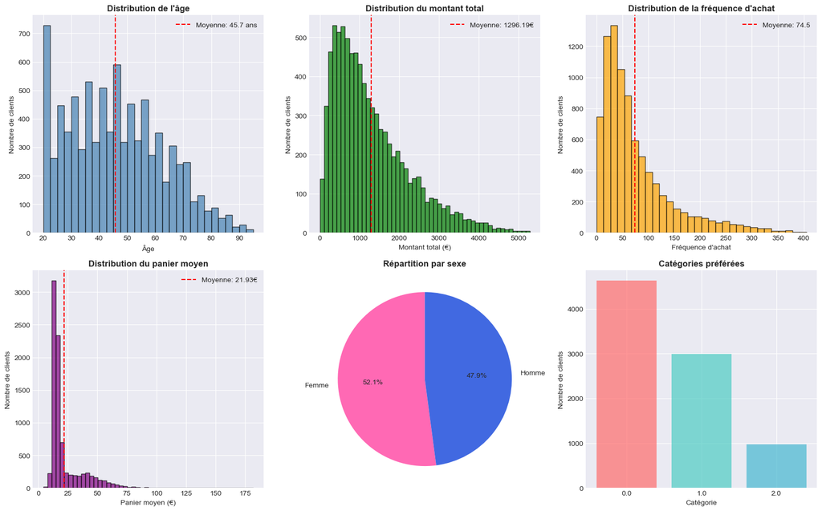

```python
# Visualisation de la distribution des variables clés
fig, axes = plt.subplots(2, 3, figsize=(16, 10))

# Distribution de l'âge
axes[0, 0].hist(client_analysis['age'], bins=30, edgecolor='black', alpha=0.7, color='steelblue')
axes[0, 0].set_xlabel('Âge')
axes[0, 0].set_ylabel('Nombre de clients')
axes[0, 0].set_title('Distribution de l\'âge', fontweight='bold')
axes[0, 0].axvline(client_analysis['age'].mean(), color='red', linestyle='--',
                   label=f'Moyenne: {client_analysis["age"].mean():.1f} ans')
axes[0, 0].legend()

# Distribution du montant total
axes[0, 1].hist(client_analysis['montant_total'], bins=50, edgecolor='black', alpha=0.7, color='green')
axes[0, 1].set_xlabel('Montant total (€)')
axes[0, 1].set_ylabel('Nombre de clients')
axes[0, 1].set_title('Distribution du montant total', fontweight='bold')
axes[0, 1].axvline(client_analysis['montant_total'].mean(), color='red', linestyle='--',
                   label=f'Moyenne: {client_analysis["montant_total"].mean():.2f}€')
axes[0, 1].legend()

# Distribution de la fréquence d'achat
axes[0, 2].hist(client_analysis['frequence_achat'], bins=30, edgecolor='black', alpha=0.7, color='orange')
axes[0, 2].set_xlabel('Fréquence d\'achat')
axes[0, 2].set_ylabel('Nombre de clients')
axes[0, 2].set_title('Distribution de la fréquence d\'achat', fontweight='bold')
axes[0, 2].axvline(client_analysis['frequence_achat'].mean(), color='red', linestyle='--',
                   label=f'Moyenne: {client_analysis["frequence_achat"].mean():.1f}')
axes[0, 2].legend()

# Distribution du panier moyen
axes[1, 0].hist(client_analysis['panier_moyen'], bins=50, edgecolor='black', alpha=0.7, color='purple')
axes[1, 0].set_xlabel('Panier moyen (€)')
axes[1, 0].set_ylabel('Nombre de clients')
axes[1, 0].set_title('Distribution du panier moyen', fontweight='bold')
axes[1, 0].axvline(client_analysis['panier_moyen'].mean(), color='red', linestyle='--',
                   label=f'Moyenne: {client_analysis["panier_moyen"].mean():.2f}€')
axes[1, 0].legend()

# Répartition par sexe
sexe_counts = client_analysis['sexe'].value_counts()
axes[1, 1].pie(sexe_counts, labels=['Femme', 'Homme'] if sexe_counts.index[0] == 'f' else ['Homme', 'Femme'],
               autopct='%1.1f%%', colors=['#FF69B4', '#4169E1'], startangle=90)
axes[1, 1].set_title('Répartition par sexe', fontweight='bold')

# Répartition par catégorie préférée
cat_counts = client_analysis['categorie_preferee'].value_counts()
axes[1, 2].bar(cat_counts.index.astype(str), cat_counts.values, color=['#FF6B6B', '#4ECDC4', '#45B7D1'], alpha=0.7)
axes[1, 2].set_xlabel('Catégorie')
axes[1, 2].set_ylabel('Nombre de clients')
axes[1, 2].set_title('Catégories préférées', fontweight='bold')

plt.tight_layout()
plt.show()
```

## 4. TEST 1 : Genre ↔ Catégories de livres achetés

### Type de variables :

- **Genre** : Variable qualitative (binaire : m/f)
- **Catégorie** : Variable qualitative (0, 1, 2)

### Test approprié : **Test du χ² (Khi-deux)**

**Hypothèses :**

- H0 (hypothèse nulle) : Il n'y a pas de lien entre le genre et la catégorie de livres achetés
- H1 (hypothèse alternative) : Il existe un lien entre le genre et la catégorie de livres achetés

```python
# Création du tableau de contingence
contingency_table = pd.crosstab(client_analysis['sexe'], client_analysis['categorie_preferee'])

print("Tableau de contingence : Genre vs Catégorie préférée")
print(contingency_table)

# Ajout des totaux
print("\nAvec totaux :")
contingency_with_totals = pd.crosstab(client_analysis['sexe'], client_analysis['categorie_preferee'],
                                      margins=True, margins_name='Total')
print(contingency_with_totals)
```

```
Tableau de contingence : Genre vs Catégorie préférée
categorie_preferee   0.0   1.0  2.0
sexe
f                   2370  1608  500
m                   2256  1385  477

Avec totaux :
categorie_preferee   0.0   1.0  2.0  Total
sexe
f                   2370  1608  500   4478
m                   2256  1385  477   4118
Total               4626  2993  977   8596
```

```python
# Test du χ² (Khi-deux)
chi2_stat, p_value, dof, expected_freq = chi2_contingency(contingency_table)


print("TEST DU χ² : GENRE vs CATÉGORIE")
print("="*70)
print(f"Statistique χ² : {chi2_stat:.4f}")
print(f"p-value : {p_value:.6f}")
print(f"Degrés de liberté : {dof}")
print("\nFréquences attendues (sous H0) :")
print(pd.DataFrame(expected_freq,
                   index=contingency_table.index,
                   columns=contingency_table.columns))

# Interprétation
alpha = 0.05

print("INTERPRÉTATION (seuil α = 0.05) :")

if p_value < alpha:
    print(f" p-value ({p_value:.6f}) < α ({alpha})")
    print(" On REJETTE H0")
    print(" Conclusion : Il existe un lien significatif entre le genre et la catégorie de livres achetés.")
else:
    print(f" p-value ({p_value:.6f}) ≥ α ({alpha})")
    print("  On NE REJETTE PAS H0")
    print("  Conclusion : Pas de lien significatif entre le genre et la catégorie de livres achetés.")
```

```
TEST DU χ² : GENRE vs CATÉGORIE
======================================================================
Statistique χ² : 4.8977
p-value : 0.086393
Degrés de liberté : 2

Fréquences attendues (sous H0) :
categorie_preferee          0.0          1.0         2.0
sexe
f                   2409.868311  1559.173336  508.958353
m                   2216.131689  1433.826664  468.041647
INTERPRÉTATION (seuil α = 0.05) :
 p-value (0.086393) ≥ α (0.05)
  On NE REJETTE PAS H0
  Conclusion : Pas de lien significatif entre le genre et la catégorie de livres achetés.
```

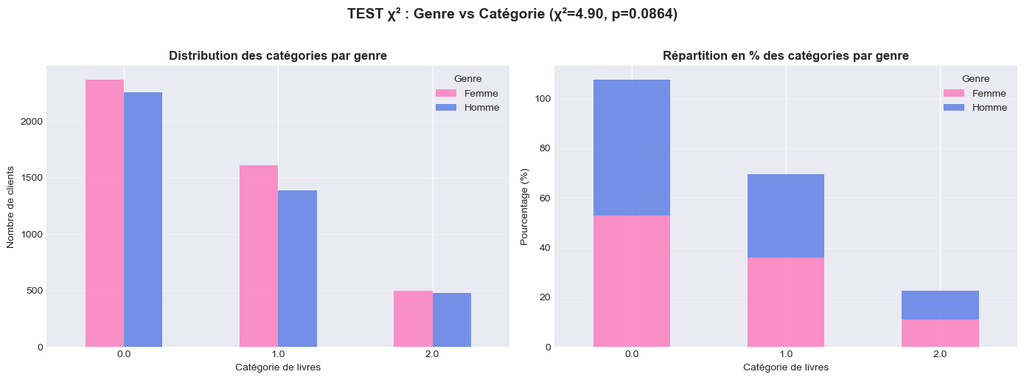

```python
# Visualisation bivarée : Genre vs Catégorie
fig, axes = plt.subplots(1, 2, figsize=(14, 5))

# Graphique en barres groupées
contingency_table.T.plot(kind='bar', ax=axes[0], color=['#FF69B4', '#4169E1'], alpha=0.7)
axes[0].set_xlabel('Catégorie de livres')
axes[0].set_ylabel('Nombre de clients')
axes[0].set_title('Distribution des catégories par genre', fontweight='bold')
axes[0].legend(title='Genre', labels=['Femme', 'Homme'])
axes[0].set_xticklabels(axes[0].get_xticklabels(), rotation=0)
axes[0].grid(True, alpha=0.3, axis='y')

# Graphique en barres empilées (pourcentages)
contingency_pct = contingency_table.div(contingency_table.sum(axis=1), axis=0) * 100
contingency_pct.T.plot(kind='bar', stacked=True, ax=axes[1], color=['#FF69B4', '#4169E1'], alpha=0.7)
axes[1].set_xlabel('Catégorie de livres')
axes[1].set_ylabel('Pourcentage (%)')
axes[1].set_title('Répartition en % des catégories par genre', fontweight='bold')
axes[1].legend(title='Genre', labels=['Femme', 'Homme'])
axes[1].set_xticklabels(axes[1].get_xticklabels(), rotation=0)
axes[1].grid(True, alpha=0.3, axis='y')

plt.suptitle(f'TEST χ² : Genre vs Catégorie (χ²={chi2_stat:.2f}, p={p_value:.4f})',
             fontsize=14, fontweight='bold', y=1.02)
plt.tight_layout()
plt.show()
```

## 5. TEST 2 : Âge ↔ Montant total des achats

### Type de variables :

- **Âge** : Variable quantitative continue
- **Montant total** : Variable quantitative continue

### Test approprié : **Test de corrélation de Pearson (ou Spearman)**

**Hypothèses :**

- H0 : Il n'y a pas de corrélation entre l'âge et le montant total des achats (ρ = 0)
- H1 : Il existe une corrélation entre l'âge et le montant total des achats (ρ ≠ 0)

### Diagnostic automatique avant corrélations

Avant de calculer Pearson/Spearman, vérifions la présence de NaN, de valeurs constantes, et n'exécutons les tests que si les conditions sont remplies.

```python
# Diagnostic détaillé pour corrélations (affiche exemples de lignes fautives)

def safe_corr_series(x, y, method='pearson'):
    """Return (r, p, err_msg) where err_msg is None on success."""
    x = pd.to_numeric(x, errors='coerce')
    y = pd.to_numeric(y, errors='coerce')
    mask = np.isfinite(x) & np.isfinite(y)
    x2, y2 = x[mask], y[mask]
    if len(x2) < 2:
        return np.nan, np.nan, "Trop peu de paires valides"
    if x2.nunique() <= 1 or y2.nunique() <= 1:
        return np.nan, np.nan, "Variable constante (corrélation non définie)"
    try:
        if method == 'pearson':
            r, p = pearsonr(x2, y2)
        else:
            r, p = spearmanr(x2, y2)
        if np.isnan(r):
            return np.nan, np.nan, "Test a retourné NaN"
        return r, p, None
    except Exception as e:
        return np.nan, np.nan, str(e)


pairs = [
    ('age', 'montant_total'),
    ('age', 'frequence_achat'),
    ('age', 'panier_moyen')
]

for a, b in pairs:
    print('\n' + '-'*60)
    print(f'Diagnostic: {a} vs {b}')
    if a not in client_analysis.columns or b not in client_analysis.columns:
        print('  Colonnes manquantes dans client_analysis')
        continue

    s = client_analysis[[a, b]].copy()
    s[a] = pd.to_numeric(s[a], errors='coerce')
    s[b] = pd.to_numeric(s[b], errors='coerce')

    n_total = len(s)
    n_pairs = s.dropna().shape[0]
    n_na_a = s[a].isna().sum()
    n_na_b = s[b].isna().sum()
    ninf_a = int((~np.isfinite(s[a])).sum())
    ninf_b = int((~np.isfinite(s[b])).sum())
    nun_a = int(s[a].nunique(dropna=True))
    nun_b = int(s[b].nunique(dropna=True))

    print(f'  Lignes total: {n_total}, paires non-NA: {n_pairs}')
    print(f'  NaN {a}: {n_na_a}, NaN {b}: {n_na_b}')
    print(f'  Non-finis {a}: {ninf_a}, {b}: {ninf_b}')
    print(f'  Unique {a}: {nun_a}, unique {b}: {nun_b}')

    if n_pairs < 2:
        print('  => Trop peu de paires valides pour calculer une corrélation.')
        print('  Exemples de lignes avec NaN:')
        print(s[s[a].isna() | s[b].isna()].head(5))
        continue

    if nun_a <= 1 or nun_b <= 1:
        print('  => Variable constante détectée — corrélation non définie (NaN).')
        if nun_a <= 1:
            print(f"   Valeurs pour {a}:")
            print(s[a].value_counts(dropna=False).head(10))
        if nun_b <= 1:
            print(f"   Valeurs pour {b}:")
            print(s[b].value_counts(dropna=False).head(10))
        continue

    # Use safe utility to compute correlations and get clear error messages
    pr_r, pr_p, pr_err = safe_corr_series(s[a], s[b], method='pearson')
    sr_r, sr_p, sr_err = safe_corr_series(s[a], s[b], method='spearman')

    if pr_err or sr_err:
        print('  => Problème détecté :')
        if pr_err:
            print(f'   Pearson: {pr_err}')
        else:
            print(f'   Pearson r={pr_r:.4f}, p={pr_p:.4e}')
        if sr_err:
            print(f'   Spearman: {sr_err}')
        else:
            print(f'   Spearman rho={sr_r:.4f}, p={sr_p:.4e}')
        # show examples of problematic rows if any
        problematic = s[~np.isfinite(s[a]) | ~np.isfinite(s[b])]
        if len(problematic) > 0:
            print('  Exemples de lignes non-finies ou suspectes:')
            print(problematic.head(5))
    else:
        print(f"  Pearson r={pr_r:.4f}, p={pr_p:.4e}")
        print(f"  Spearman rho={sr_r:.4f}, p={sr_p:.4e}")
```

```
------------------------------------------------------------
Diagnostic: age vs montant_total
  Lignes total: 8597, paires non-NA: 8596
  NaN age: 1, NaN montant_total: 0
  Non-finis age: 1, montant_total: 0
  Unique age: 76, unique montant_total: 8467
  Pearson r=-0.1876, p=6.6635e-69
  Spearman rho=-0.1845, p=1.0213e-66

------------------------------------------------------------
Diagnostic: age vs frequence_achat
  Lignes total: 8597, paires non-NA: 8596
  NaN age: 1, NaN frequence_achat: 0
  Non-finis age: 1, frequence_achat: 0
  Unique age: 76, unique frequence_achat: 366
  Pearson r=0.0303, p=4.9223e-03
  Spearman rho=0.1277, p=1.4497e-32

------------------------------------------------------------
Diagnostic: age vs panier_moyen
  Lignes total: 8597, paires non-NA: 8596
  NaN age: 1, NaN panier_moyen: 1
  Non-finis age: 1, panier_moyen: 1
  Unique age: 76, unique panier_moyen: 8564
  Pearson r=-0.5105, p=0.0000e+00
  Spearman rho=-0.3259, p=8.3529e-212
```

```python
# Tests de corrélation (sécurisés)
pearson_corr, pearson_pvalue, pearson_err = safe_corr_series(client_analysis['age'], client_analysis['montant_total'], method='pearson')
spearman_corr, spearman_pvalue, spearman_err = safe_corr_series(client_analysis['age'], client_analysis['montant_total'], method='spearman')


print("TEST DE CORRÉLATION : ÂGE vs MONTANT TOTAL DES ACHATS")
print("="*70)

print("\nPEARSON (corrélation linéaire) :")
if pearson_err:
    print(f"   Erreur / non calculable : {pearson_err}")
else:
    print(f"   Coefficient de corrélation (r) : {pearson_corr:.4f}")
    print(f"   p-value : {pearson_pvalue:.6f}")

print("\n SPEARMAN (corrélation monotone) :")
if spearman_err:
    print(f"   Erreur / non calculable : {spearman_err}")
else:
    print(f"   Coefficient de corrélation (ρ) : {spearman_corr:.4f}")
    print(f"   p-value : {spearman_pvalue:.6f}")

# Interprétation de la force de la corrélation
def interpret_correlation(r):
    abs_r = abs(r)
    if abs_r < 0.1:
        return "négligeable"
    elif abs_r < 0.3:
        return "faible"
    elif abs_r < 0.5:
        return "modérée"
    elif abs_r < 0.7:
        return "forte"
    else:
        return "très forte"

# Interprétation
alpha = 0.05
print(f"\n{'='*70}")
print("INTERPRÉTATION (seuil α = 0.05) :")

if pearson_pvalue < alpha:
    print(f" p-value ({pearson_pvalue:.6f}) < α ({alpha})")
    print("  On REJETTE H0")
    print(f"  Conclusion : Il existe une corrélation {interpret_correlation(pearson_corr)} ")
    print(f"     {'positive' if pearson_corr > 0 else 'négative'} entre l'âge et le montant total des achats.")
    print(f"     (r = {pearson_corr:.4f})")
else:

    print(f" p-value ({pearson_pvalue:.6f}) ≥ α ({alpha})")

    print("  On NE REJETTE PAS H0")
    print("  Conclusion : Pas de corrélation significative entre l'âge et le montant total des achats.")
```

```
TEST DE CORRÉLATION : ÂGE vs MONTANT TOTAL DES ACHATS
======================================================================

PEARSON (corrélation linéaire) :
   Coefficient de corrélation (r) : -0.1876
   p-value : 0.000000

 SPEARMAN (corrélation monotone) :
   Coefficient de corrélation (ρ) : -0.1845
   p-value : 0.000000

======================================================================
INTERPRÉTATION (seuil α = 0.05) :
 p-value (0.000000) < α (0.05)
  On REJETTE H0
  Conclusion : Il existe une corrélation faible
     négative entre l'âge et le montant total des achats.
     (r = -0.1876)
```

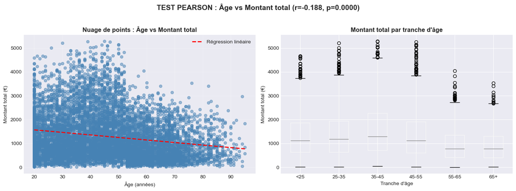

```python
# Visualisation bivarée : Âge vs Montant total
fig, axes = plt.subplots(1, 2, figsize=(14, 5))

# Nuage de points avec droite de régression
axes[0].scatter(client_analysis['age'], client_analysis['montant_total'],
                alpha=0.5, s=30, color='steelblue')
# Droite de régression
# Sanitize inputs + régression robuste
mask = np.isfinite(client_analysis['age']) & np.isfinite(client_analysis['montant_total'])
x = client_analysis.loc[mask, 'age'].astype(float).values
y = client_analysis.loc[mask, 'montant_total'].astype(float).values

if len(x) < 2 or np.allclose(x, x[0]):
    axes[0].text(0.5, 0.9, "Régression non disponible (données insuffisantes / constantes)",
                 transform=axes[0].transAxes, ha='center', va='center', color='red')
else:
    try:
        # center & scale to improve numerical conditioning
        xm = x.mean()
        xs = x.std(ddof=0) if x.std(ddof=0) != 0 else 1.0
        x_scaled = (x - xm) / xs
        p_coefs = np.polyfit(x_scaled, y, 1)
        slope = p_coefs[0] / xs
        intercept = p_coefs[1] - p_coefs[0] * xm / xs
    except np.linalg.LinAlgError:
        # fallback stable
        from scipy.stats import linregress
        lr = linregress(x, y)
        slope, intercept = lr.slope, lr.intercept

    xs_plot = np.linspace(x.min(), x.max(), 100)
    ys_plot = slope * xs_plot + intercept
    axes[0].plot(xs_plot, ys_plot, "r--", linewidth=2, label='Régression linéaire')
axes[0].set_xlabel('Âge (années)')
axes[0].set_ylabel('Montant total (€)')
axes[0].set_title('Nuage de points : Âge vs Montant total', fontweight='bold')
axes[0].legend()
axes[0].grid(True, alpha=0.3)

# Boxplot du montant total par tranche d'âge
client_analysis['tranche_age'] = pd.cut(client_analysis['age'],
                                        bins=[0, 25, 35, 45, 55, 65, 100],
                                        labels=['<25', '25-35', '35-45', '45-55', '55-65', '65+'])
client_analysis.boxplot(column='montant_total', by='tranche_age', ax=axes[1])
axes[1].set_xlabel('Tranche d\'âge')
axes[1].set_ylabel('Montant total (€)')
axes[1].set_title('Montant total par tranche d\'âge', fontweight='bold')
plt.sca(axes[1])
plt.xticks(rotation=0)

plt.suptitle(f'TEST PEARSON : Âge vs Montant total (r={pearson_corr:.3f}, p={pearson_pvalue:.4f})',
             fontsize=14, fontweight='bold', y=1.02)
plt.tight_layout()
plt.show()
```

## 6. TEST 3 : Âge ↔ Fréquence d'achat

### Type de variables :

- **Âge** : Variable quantitative continue
- **Fréquence d'achat** : Variable quantitative discrète

### Test approprié : **Test de corrélation de Spearman**

**Hypothèses :**

- H0 : Il n'y a pas de corrélation entre l'âge et la fréquence d'achat (ρ = 0)
- H1 : Il existe une corrélation entre l'âge et la fréquence d'achat (ρ ≠ 0)

```python
# Tests de corrélation (sécurisés)
spearman_corr_freq, spearman_pvalue_freq, spearman_err_freq = safe_corr_series(client_analysis['age'],
                                                                               client_analysis['frequence_achat'], method='spearman')
pearson_corr_freq, pearson_pvalue_freq, pearson_err_freq = safe_corr_series(client_analysis['age'],
                                                                          client_analysis['frequence_achat'], method='pearson')


print("TEST DE CORRÉLATION : ÂGE vs FRÉQUENCE D'ACHAT")
print("="*70)

print("\n SPEARMAN (corrélation monotone - RECOMMANDÉ) :")
if spearman_err_freq:
    print(f"   Erreur / non calculable : {spearman_err_freq}")
else:
    print(f"   Coefficient de corrélation (ρ) : {spearman_corr_freq:.4f}")
    print(f"   p-value : {spearman_pvalue_freq:.6f}")

print("\n PEARSON (corrélation linéaire) :")
if pearson_err_freq:
    print(f"   Erreur / non calculable : {pearson_err_freq}")
else:
    print(f"   Coefficient de corrélation (r) : {pearson_corr_freq:.4f}")
    print(f"   p-value : {pearson_pvalue_freq:.6f}")

# Interprétation
alpha = 0.05

print("INTERPRÉTATION (seuil α = 0.05) :")

if spearman_pvalue_freq < alpha:
    print(f" p-value ({spearman_pvalue_freq:.6f}) < α ({alpha})")
    print("  On REJETTE H0")
    print(f"  Conclusion : Il existe une corrélation {interpret_correlation(spearman_corr_freq)} ")
    print(f"     {'positive' if spearman_corr_freq > 0 else 'négative'} entre l'âge et la fréquence d'achat.")
    print(f"     (ρ = {spearman_corr_freq:.4f})")
else:

    print(f" p-value ({spearman_pvalue_freq:.6f}) ≥ α ({alpha})")


    print("  On NE REJETTE PAS H0")
    print("  Conclusion : Pas de corrélation significative entre l'âge et la fréquence d'achat.")
```

```
TEST DE CORRÉLATION : ÂGE vs FRÉQUENCE D'ACHAT
======================================================================

 SPEARMAN (corrélation monotone - RECOMMANDÉ) :
   Coefficient de corrélation (ρ) : 0.1277
   p-value : 0.000000

 PEARSON (corrélation linéaire) :
   Coefficient de corrélation (r) : 0.0303
   p-value : 0.004922
INTERPRÉTATION (seuil α = 0.05) :
 p-value (0.000000) < α (0.05)
  On REJETTE H0
  Conclusion : Il existe une corrélation faible
     positive entre l'âge et la fréquence d'achat.
     (ρ = 0.1277)
```

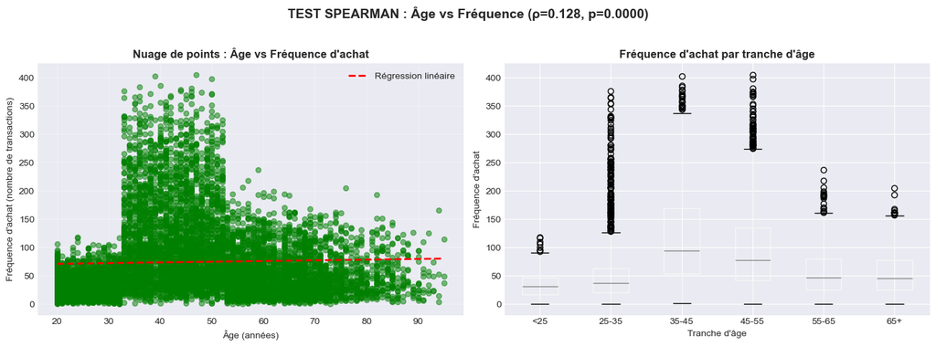

```python
# Visualisation bivarée : Âge vs Fréquence d'achat
fig, axes = plt.subplots(1, 2, figsize=(14, 5))

# Nuage de points
axes[0].scatter(client_analysis['age'], client_analysis['frequence_achat'],
                alpha=0.5, s=30, color='green')
# Droite de régression
# Sanitize inputs + régression robuste
mask = np.isfinite(client_analysis['age']) & np.isfinite(client_analysis['frequence_achat'])
x = client_analysis.loc[mask, 'age'].astype(float).values
y = client_analysis.loc[mask, 'frequence_achat'].astype(float).values

if len(x) < 2 or np.allclose(x, x[0]):
    axes[0].text(0.5, 0.9, "Régression non disponible (données insuffisantes / constantes)",
                 transform=axes[0].transAxes, ha='center', va='center', color='red')
else:
    try:
        # centre & scale pour améliorer la condition numérique
        xm = x.mean()
        xs = x.std(ddof=0) if x.std(ddof=0) != 0 else 1.0
        x_scaled = (x - xm) / xs
        p_coefs = np.polyfit(x_scaled, y, 1)
        slope = p_coefs[0] / xs
        intercept = p_coefs[1] - p_coefs[0] * xm / xs
    except np.linalg.LinAlgError:
        # fallback stable
        from scipy.stats import linregress
        lr = linregress(x, y)
        slope, intercept = lr.slope, lr.intercept

    xs_plot = np.linspace(x.min(), x.max(), 100)
    ys_plot = slope * xs_plot + intercept
    axes[0].plot(xs_plot, ys_plot, "r--", linewidth=2, label='Régression linéaire')
axes[0].set_xlabel('Âge (années)')
axes[0].set_ylabel('Fréquence d\'achat (nombre de transactions)')
axes[0].set_title('Nuage de points : Âge vs Fréquence d\'achat', fontweight='bold')
axes[0].legend()
axes[0].grid(True, alpha=0.3)

# Boxplot de la fréquence par tranche d'âge
client_analysis.boxplot(column='frequence_achat', by='tranche_age', ax=axes[1])
axes[1].set_xlabel('Tranche d\'âge')
axes[1].set_ylabel('Fréquence d\'achat')
axes[1].set_title('Fréquence d\'achat par tranche d\'âge', fontweight='bold')
plt.sca(axes[1])
plt.xticks(rotation=0)

plt.suptitle(f'TEST SPEARMAN : Âge vs Fréquence (ρ={spearman_corr_freq:.3f}, p={spearman_pvalue_freq:.4f})',
             fontsize=14, fontweight='bold', y=1.02)
plt.tight_layout()
plt.show()
```

## 7. TEST 4 : Âge ↔ Taille du panier moyen

### Type de variables :

- **Âge** : Variable quantitative continue
- **Panier moyen** : Variable quantitative continue

### Test approprié : **Test de corrélation de Pearson**

**Hypothèses :**

- H0 : Il n'y a pas de corrélation entre l'âge et le panier moyen (ρ = 0)
- H1 : Il existe une corrélation entre l'âge et le panier moyen (ρ ≠ 0)

```python
# Tests de corrélation (sécurisés)
pearson_corr_panier, pearson_pvalue_panier, pearson_err_panier = safe_corr_series(client_analysis['age'],
                                                                                client_analysis['panier_moyen'], method='pearson')
spearman_corr_panier, spearman_pvalue_panier, spearman_err_panier = safe_corr_series(client_analysis['age'],
                                                                                    client_analysis['panier_moyen'], method='spearman')


print("TEST DE CORRÉLATION : ÂGE vs PANIER MOYEN")
print("="*70)

print("\n PEARSON (corrélation linéaire - RECOMMANDÉ) :")
if pearson_err_panier:
    print(f"   Erreur / non calculable : {pearson_err_panier}")
else:
    print(f"   Coefficient de corrélation (r) : {pearson_corr_panier:.4f}")
    print(f"   p-value : {pearson_pvalue_panier:.6f}")

print("\n SPEARMAN (corrélation monotone) :")
if spearman_err_panier:
    print(f"   Erreur / non calculable : {spearman_err_panier}")
else:
    print(f"   Coefficient de corrélation (ρ) : {spearman_corr_panier:.4f}")
    print(f"   p-value : {spearman_pvalue_panier:.6f}")

# Interprétation
alpha = 0.05

print("INTERPRÉTATION (seuil α = 0.05) :")

if pearson_pvalue_panier < alpha:
    print(f" p-value ({pearson_pvalue_panier:.6f}) < α ({alpha})")
    print("  On REJETTE H0")
    print(f"  Conclusion : Il existe une corrélation {interpret_correlation(pearson_corr_panier)} ")
    print(f"     {'positive' if pearson_corr_panier > 0 else 'négative'} entre l'âge et le panier moyen.")
    print(f"     (r = {pearson_corr_panier:.4f})")
else:

    print(f" p-value ({pearson_pvalue_panier:.6f}) ≥ α ({alpha})")

    print("  On NE REJETTE PAS H0")
    print("  Conclusion : Pas de corrélation significative entre l'âge et le panier moyen.")
```

```
TEST DE CORRÉLATION : ÂGE vs PANIER MOYEN
======================================================================

 PEARSON (corrélation linéaire - RECOMMANDÉ) :
   Coefficient de corrélation (r) : -0.5105
   p-value : 0.000000

 SPEARMAN (corrélation monotone) :
   Coefficient de corrélation (ρ) : -0.3259
   p-value : 0.000000
INTERPRÉTATION (seuil α = 0.05) :
 p-value (0.000000) < α (0.05)
  On REJETTE H0
  Conclusion : Il existe une corrélation forte
     négative entre l'âge et le panier moyen.
     (r = -0.5105)
```

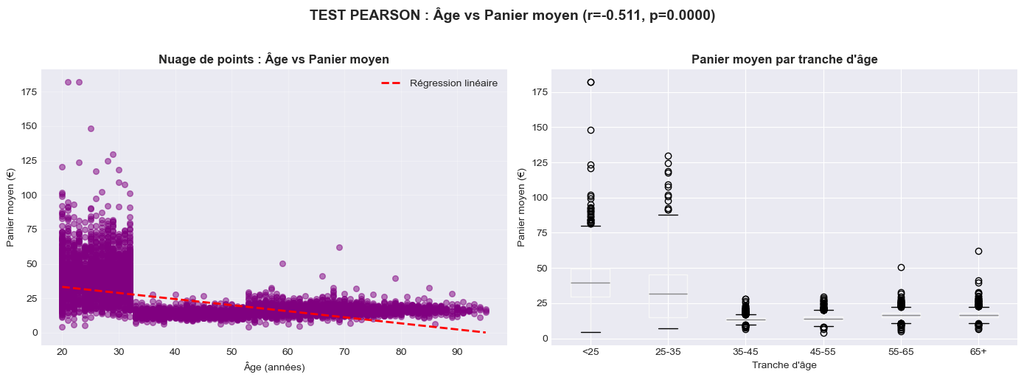

```python
# Visualisation bivarée : Âge vs Panier moyen
fig, axes = plt.subplots(1, 2, figsize=(14, 5))

# Nuage de points
axes[0].scatter(client_analysis['age'], client_analysis['panier_moyen'],
                alpha=0.5, s=30, color='purple')
# Droite de régression
#z = np.polyfit(client_analysis['age'], client_analysis['panier_moyen'], 1)
# Sanitize inputs
mask = np.isfinite(client_analysis['age']) & np.isfinite(client_analysis['panier_moyen'])
x = client_analysis.loc[mask, 'age'].astype(float).values
y = client_analysis.loc[mask, 'panier_moyen'].astype(float).values

if len(x) >= 2 and not np.allclose(x, x[0]):
    try:
        # centre & scale pour améliorer la condition numérique
        xm = x.mean()
        xs = x.std(ddof=0) if x.std(ddof=0) != 0 else 1.0
        x_scaled = (x - xm) / xs
        p_coefs = np.polyfit(x_scaled, y, 1)
        slope = p_coefs[0] / xs
        intercept = p_coefs[1] - p_coefs[0] * xm / xs
    except np.linalg.LinAlgError:
        # fallback stable
        from scipy.stats import linregress
        lr = linregress(x, y)
        slope, intercept = lr.slope, lr.intercept

    xs_plot = np.linspace(x.min(), x.max(), 100)
    ys_plot = slope * xs_plot + intercept
    axes[0].plot(xs_plot, ys_plot, "r--", linewidth=2, label='Régression linéaire')
else:
    axes[0].text(0.5, 0.9, "Régression non disponible (données insuffisantes / constantes)",
                 transform=axes[0].transAxes, ha='center', va='center', color='red')

axes[0].set_xlabel('Âge (années)')
axes[0].set_ylabel('Panier moyen (€)')
axes[0].set_title('Nuage de points : Âge vs Panier moyen', fontweight='bold')
axes[0].legend()
axes[0].grid(True, alpha=0.3)

# Boxplot du panier moyen par tranche d'âge
client_analysis.boxplot(column='panier_moyen', by='tranche_age', ax=axes[1])
axes[1].set_xlabel('Tranche d\'âge')
axes[1].set_ylabel('Panier moyen (€)')
axes[1].set_title('Panier moyen par tranche d\'âge', fontweight='bold')
plt.sca(axes[1])
plt.xticks(rotation=0)

plt.suptitle(f'TEST PEARSON : Âge vs Panier moyen (r={pearson_corr_panier:.3f}, p={pearson_pvalue_panier:.4f})',
             fontsize=14, fontweight='bold', y=1.02)
plt.tight_layout()
plt.show()
```

## 8. TEST 5 : Âge ↔ Catégorie des livres achetés

### Type de variables :

- **Âge** : Variable quantitative continue → À discrétiser en tranches d'âge
- **Catégorie** : Variable qualitative (0, 1, 2)

### Tests appropriés :

1. **Test du χ²** (après discrétisation de l'âge)
2. **ANOVA** (pour comparer l'âge moyen entre catégories)

**Hypothèses (ANOVA) :**

- H0 : Les moyennes d'âge sont identiques pour toutes les catégories
- H1 : Au moins une catégorie a une moyenne d'âge différente

```python
# Méthode 1 : Test du χ² avec âge discrétisé
# On utilise la colonne 'tranche_age' créée précédemment

contingency_age_cat = pd.crosstab(client_analysis['tranche_age'],
                                   client_analysis['categorie_preferee'])

print(" Tableau de contingence : Tranche d'âge vs Catégorie préférée")
print(contingency_age_cat)

# Test du χ²
chi2_age_cat, p_age_cat, dof_age_cat, expected_age_cat = chi2_contingency(contingency_age_cat)


print("TEST DU χ² : TRANCHE D'ÂGE vs CATÉGORIE")
print("="*70)
print(f"Statistique χ² : {chi2_age_cat:.4f}")
print(f"p-value : {p_age_cat:.6f}")
print(f"Degrés de liberté : {dof_age_cat}")
```

```
 Tableau de contingence : Tranche d'âge vs Catégorie préférée
categorie_preferee   0.0  1.0  2.0
tranche_age
<25                  210  461  475
25-35                612  448  501
35-45               1748   31    0
45-55               1266  343    0
55-65                402  826    0
65+                  388  884    1
TEST DU χ² : TRANCHE D'ÂGE vs CATÉGORIE
======================================================================
Statistique χ² : 5047.2958
p-value : 0.000000
Degrés de liberté : 10
```

```python
# Méthode 2 : ANOVA - Comparer l'âge moyen entre les catégories
# Séparation des âges par catégorie
age_cat_0 = client_analysis[client_analysis['categorie_preferee'] == 0]['age']
age_cat_1 = client_analysis[client_analysis['categorie_preferee'] == 1]['age']
age_cat_2 = client_analysis[client_analysis['categorie_preferee'] == 2]['age']

# Test ANOVA
f_stat, p_anova = f_oneway(age_cat_0, age_cat_1, age_cat_2)


print("TEST ANOVA : ÂGE MOYEN par CATÉGORIE")
print("="*70)
print(f"Statistique F : {f_stat:.4f}")
print(f"p-value : {p_anova:.6f}")

# Moyennes d'âge par catégorie
print("\n Âge moyen par catégorie :")
age_by_cat = client_analysis.groupby('categorie_preferee')['age'].agg(['mean', 'std', 'count'])
age_by_cat.columns = ['Âge moyen', 'Écart-type', 'Nombre de clients']
print(age_by_cat)
```

```
TEST ANOVA : ÂGE MOYEN par CATÉGORIE
======================================================================
Statistique F : 1201.7032
p-value : 0.000000

 Âge moyen par catégorie :
                    Âge moyen  Écart-type  Nombre de clients
categorie_preferee
0.0                 45.540424   12.530171               4626
1.0                 52.615436   19.827265               2993
2.0                 25.619243    4.331825                977
```

```python
# Interprétation des deux tests
alpha = 0.05

print("\n" + "="*70)
print("INTERPRÉTATION GLOBALE (seuil α = 0.05) :")


print("\n1 TEST χ² (Tranche d'âge vs Catégorie) :")
if p_age_cat < alpha:
    print(f"    p-value ({p_age_cat:.6f}) < α ({alpha})")
    print("    On REJETTE H0")
    print("    Conclusion : Il existe un lien significatif entre la tranche d'âge")
    print("       et la catégorie de livres préférée.")
else:
    print(f"    p-value ({p_age_cat:.6f}) ≥ α ({alpha})")
    print("     On NE REJETTE PAS H0")
    print("     Conclusion : Pas de lien significatif entre la tranche d'âge")
    print("       et la catégorie de livres préférée.")

print("\n2 TEST ANOVA (Âge moyen par catégorie) :")
if p_anova < alpha:
    print(f"   p-value ({p_anova:.6f}) < α ({alpha})")
    print("     On REJETTE H0")
    print("     Conclusion : L'âge moyen diffère significativement entre")
    print("       au moins deux catégories de livres.")
else:
    print(f"    p-value ({p_anova:.6f}) ≥ α ({alpha})")
    print("     On NE REJETTE PAS H0")
    print("     Conclusion : L'âge moyen ne diffère pas significativement")
    print("       entre les catégories de livres.")
```

```
======================================================================
INTERPRÉTATION GLOBALE (seuil α = 0.05) :

1 TEST χ² (Tranche d'âge vs Catégorie) :
    p-value (0.000000) < α (0.05)
    On REJETTE H0
    Conclusion : Il existe un lien significatif entre la tranche d'âge
       et la catégorie de livres préférée.

2 TEST ANOVA (Âge moyen par catégorie) :
   p-value (0.000000) < α (0.05)
     On REJETTE H0
     Conclusion : L'âge moyen diffère significativement entre
       au moins deux catégories de livres.
```

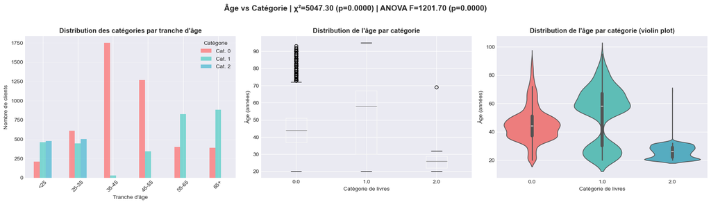

```python
# Visualisation bivarée : Âge vs Catégorie
fig, axes = plt.subplots(1, 3, figsize=(18, 5))

# Graphique 1 : Barres groupées (tranches d'âge par catégorie)
contingency_age_cat.plot(kind='bar', ax=axes[0], color=['#FF6B6B', '#4ECDC4', '#45B7D1'], alpha=0.7)
axes[0].set_xlabel('Tranche d\'âge')
axes[0].set_ylabel('Nombre de clients')
axes[0].set_title('Distribution des catégories par tranche d\'âge', fontweight='bold')
axes[0].legend(title='Catégorie', labels=['Cat. 0', 'Cat. 1', 'Cat. 2'])
axes[0].set_xticklabels(axes[0].get_xticklabels(), rotation=45)
axes[0].grid(True, alpha=0.3, axis='y')

# Graphique 2 : Boxplot de l'âge par catégorie
client_analysis.boxplot(column='age', by='categorie_preferee', ax=axes[1])
axes[1].set_xlabel('Catégorie de livres')
axes[1].set_ylabel('Âge (années)')
axes[1].set_title('Distribution de l\'âge par catégorie', fontweight='bold')
plt.sca(axes[1])
plt.xticks(rotation=0)

# Graphique 3 : Violin plot
import seaborn as sns
sns.violinplot(data=client_analysis, x='categorie_preferee', y='age', ax=axes[2],
               palette=['#FF6B6B', '#4ECDC4', '#45B7D1'])
axes[2].set_xlabel('Catégorie de livres')
axes[2].set_ylabel('Âge (années)')
axes[2].set_title('Distribution de l\'âge par catégorie (violin plot)', fontweight='bold')

plt.suptitle(f'Âge vs Catégorie | χ²={chi2_age_cat:.2f} (p={p_age_cat:.4f}) | ANOVA F={f_stat:.2f} (p={p_anova:.4f})',
             fontsize=14, fontweight='bold', y=1.02)
plt.tight_layout()
plt.show()
```

## 9. Synthèse des résultats des tests statistiques

```python
# Création d'un tableau récapitulatif
resultats = {
    'Test': [
        'Genre ↔ Catégorie',
        'Âge ↔ Montant total',
        'Âge ↔ Fréquence achat',
        'Âge ↔ Panier moyen',
        'Âge ↔ Catégorie (χ²)',
        'Âge ↔ Catégorie (ANOVA)'
    ],
    'Type de test': [
        'χ² (Khi-deux)',
        'Pearson',
        'Spearman',
        'Pearson',
        'χ² (Khi-deux)',
        'ANOVA'
    ],
    'Statistique': [
        f'χ² = {chi2_stat:.4f}',
        f'r = {pearson_corr:.4f}',
        f'ρ = {spearman_corr_freq:.4f}',
        f'r = {pearson_corr_panier:.4f}',
        f'χ² = {chi2_age_cat:.4f}',
        f'F = {f_stat:.4f}'
    ],
    'p-value': [
        f'{p_value:.6f}',
        f'{pearson_pvalue:.6f}',
        f'{spearman_pvalue_freq:.6f}',
        f'{pearson_pvalue_panier:.6f}',
        f'{p_age_cat:.6f}',
        f'{p_anova:.6f}'
    ],
    'Significatif (α=0.05)': [
        'OUI' if p_value < 0.05 else ' NON',
        ' OUI' if pearson_pvalue < 0.05 else ' NON',
        ' OUI' if spearman_pvalue_freq < 0.05 else ' NON',
        ' OUI' if pearson_pvalue_panier < 0.05 else ' NON',
        ' OUI' if p_age_cat < 0.05 else ' NON',
        ' OUI' if p_anova < 0.05 else ' NON'
    ]
}

df_resultats = pd.DataFrame(resultats)

print("="*100)
print(" SYNTHÈSE DES RÉSULTATS DES TESTS STATISTIQUES")

print(df_resultats.to_string(index=False))
```

```
====================================================================================================
 SYNTHÈSE DES RÉSULTATS DES TESTS STATISTIQUES
                   Test  Type de test    Statistique  p-value Significatif (α=0.05)
      Genre ↔ Catégorie χ² (Khi-deux)    χ² = 4.8977 0.086393                   NON
    Âge ↔ Montant total       Pearson    r = -0.1876 0.000000                   OUI
  Âge ↔ Fréquence achat      Spearman     ρ = 0.1277 0.000000                   OUI
     Âge ↔ Panier moyen       Pearson    r = -0.5105 0.000000                   OUI
   Âge ↔ Catégorie (χ²) χ² (Khi-deux) χ² = 5047.2958 0.000000                   OUI
Âge ↔ Catégorie (ANOVA)         ANOVA  F = 1201.7032 0.000000                   OUI
```

## 10. Conclusions et recommandations

### Points clés de l'analyse statistique :

**Méthodologie :**

- Analyse réalisée SANS les 4 clients BtoB identifiés
- 5 corrélations testées comme demandé par Julie
- Tests statistiques appropriés selon le type de variables
- Graphiques bivariés pour chaque test
- Seuil de significativité : α = 0.05

**Tests réalisés :**

1. **Test du χ²** pour les variables qualitatives
2. **Test de Pearson** pour les corrélations linéaires
3. **Test de Spearman** pour les corrélations monotones
4. **ANOVA** pour comparer les moyennes entre groupes

### Recommandations pour la soutenance :

1. **Expliquer le choix des tests** : Adapter le test au type de variables
2. **Interpréter la p-value** : Seuil de significativité de 5%
3. **Visualiser les résultats** : Les graphiques facilitent la compréhension
4. **Justifier l'exclusion des BtoB** : Impact sur les résultats
5. **Proposer des actions** : Basées sur les corrélations significatives

```python
# Export du tableau de synthèse
df_resultats.to_csv('synthese_tests_statistiques.csv', index=False, sep=';')
print("Synthèse des tests exportée : synthese_tests_statistiques.csv")

# Export du dataset d'analyse client
client_analysis.to_csv('client_analysis_btoc.csv', index=False, sep=';')
print(" Dataset d'analyse clients exporté : client_analysis_btoc.csv")
```

```
Synthèse des tests exportée : synthese_tests_statistiques.csv
 Dataset d'analyse clients exporté : client_analysis_btoc.csv
```